# Demand Forecasting

Context Demand forecasting is the process of predicting what the demand for certain products will be in the future. This helps manufacturers to decide what they should produce and guides retailers toward what they should stock. Demand forecasting is aimed at improving the processes of Supplier relationship management, Customer relationship management, Order fulfillment and logistics and Marketing campaigns.

Business Problem Create a 3-month demand forecasting model for the relevant retailer using the time series and machine learning techniques. The data set includes 5 years of data for 10 different stores and 50 different products of a chain of stores between 2013–01–01 and 2017–12–31.

Task Details 1. IMPORTING LIBRARIES AND DATA 2. EXPLORATORY DATA ANALYSIS 3. FEATURE ENGINEERING & DATA PRE-PROCESSING 3.1 Date Features 3.2 Random Noise 3.3 Lag/Shifted Features 3.4 Rolling Mean Features 3.5 Exponentially Weighted Mean Features 3.6 One-Hot Encoding 3.7 Converting sales to log(1+sales) 4. MODEL 4.1 Time-Based Validation Sets 4.2 LightGBM Model 4.3 Feature Importance 4.4 Final Model 5. SUBMISSION

Variables date : Date of sales data store : Unique Store ID for each store. item : Unique Item ID for each item. sales : The number of items sold from a particular store on a given date.

```python
pip install lightgbm
```

1. IMPORTING LIBRARIES AND DATA

```python
import time
import numpy as np
import pandas as pd
from matplotlib import pyplot as plt
import seaborn as sns
import lightgbm as lgb
import warnings

pd.set_option('display.max_columns', None)
pd.set_option('display.width', 500)
warnings.filterwarnings('ignore')
```

```python
train = pd.read_csv('train.csv', parse_dates=['date'])
test = pd.read_csv('test.csv', parse_dates=['date'])
#sample_sub = pd.read_csv('./input/demand-forecasting-kernels-only/sample_submission.csv')
df = pd.concat([train, test], sort=False)
```

1. EXPLORATORY DATA ANALYSIS

```python
df["date"].min(), df["date"].max()
```

```
(Timestamp('2013-01-01 00:00:00'), Timestamp('2018-03-31 00:00:00'))
```

The data starts from the 1st of the 1st month of 2013. It goes until the 31st of the 3rd month of 2018.

```python
train.shape, train.dtypes
```

```
((913000, 4),
 date     datetime64[ns]
 store             int64
 item              int64
 sales             int64
 dtype: object)
```

```python
test.shape, test.dtypes
```

```
((45000, 4),
 id                int64
 date     datetime64[ns]
 store             int64
 item              int64
 dtype: object)
```

```python
train.head()
```

|  | date | store | item | sales |
| --- | --- | --- | --- | --- |
| 0 | 2013-01-01 | 1 | 1 | 13 |
| 1 | 2013-01-02 | 1 | 1 | 11 |
| 2 | 2013-01-03 | 1 | 1 | 14 |
| 3 | 2013-01-04 | 1 | 1 | 13 |
| 4 | 2013-01-05 | 1 | 1 | 10 |

```python
test.head()
```

|  | id | date | store | item |
| --- | --- | --- | --- | --- |
| 0 | 0 | 2018-01-01 | 1 | 1 |
| 1 | 1 | 2018-01-02 | 1 | 1 |
| 2 | 2 | 2018-01-03 | 1 | 1 |
| 3 | 3 | 2018-01-04 | 1 | 1 |
| 4 | 4 | 2018-01-05 | 1 | 1 |

```python
train.isnull().sum()
```

```
date     0
store    0
item     0
sales    0
dtype: int64
```

```python
test.isnull().sum()
```

```
id       0
date     0
store    0
item     0
dtype: int64
```

```python
df.head(),df.tail()
```

```
(        date  store  item  sales  id
 0 2013-01-01      1     1   13.0 NaN
 1 2013-01-02      1     1   11.0 NaN
 2 2013-01-03      1     1   14.0 NaN
 3 2013-01-04      1     1   13.0 NaN
 4 2013-01-05      1     1   10.0 NaN,
             date  store  item  sales       id
 44995 2018-03-27     10    50    NaN  44995.0
 44996 2018-03-28     10    50    NaN  44996.0
 44997 2018-03-29     10    50    NaN  44997.0
 44998 2018-03-30     10    50    NaN  44998.0
 44999 2018-03-31     10    50    NaN  44999.0)
```

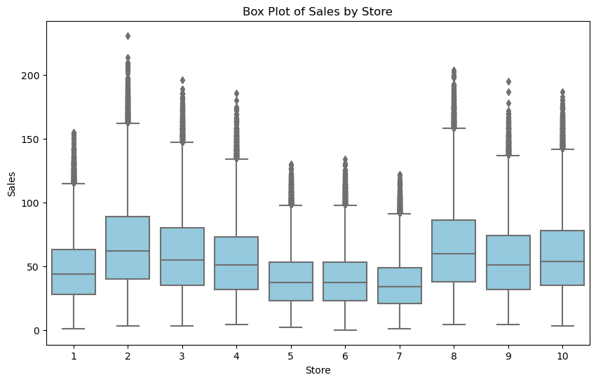

```python
# Filter out rows where 'sales' is not NaN
filtered_df = df.dropna(subset=['sales'])

# Create a box plot
plt.figure(figsize=(10, 6))
sns.boxplot(x='store', y='sales', data=filtered_df, color='skyblue')
plt.title('Box Plot of Sales by Store')
plt.xlabel('Store')
plt.ylabel('Sales')

# Show the plot
plt.show()
```

```python
# How is sales distribution?
df["sales"].describe([0.10, 0.30, 0.50, 0.70, 0.80, 0.90, 0.95, 0.99])
```

```
count    913000.000000
mean         52.250287
std          28.801144
min           0.000000
10%          20.000000
30%          33.000000
50%          47.000000
70%          64.000000
80%          76.000000
90%          93.000000
95%         107.000000
99%         135.000000
max         231.000000
Name: sales, dtype: float64
```

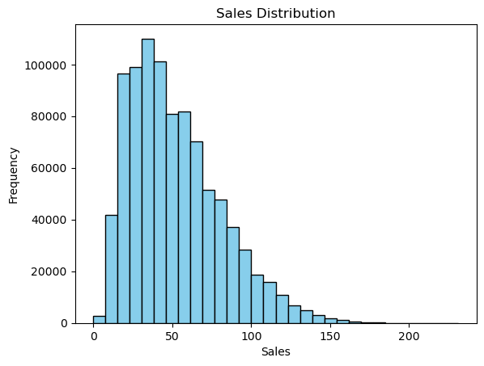

```python
# Plotting histogram
plt.hist(df["sales"], bins=30, color='skyblue', edgecolor='black')
plt.title('Sales Distribution')
plt.xlabel('Sales')
plt.ylabel('Frequency')

# Show the plot
plt.show()
```

```python
# How many stores are there?
df[["store"]].nunique()
```

```
store    10
dtype: int64
```

```python
# How many items are there?
df[["item"]].nunique()
```

```
item    50
dtype: int64
```

```python
# How many unique items are in each store?
df.groupby(["store"])["item"].nunique()
```

```
store
1     50
2     50
3     50
4     50
5     50
6     50
7     50
8     50
9     50
10    50
Name: item, dtype: int64
```

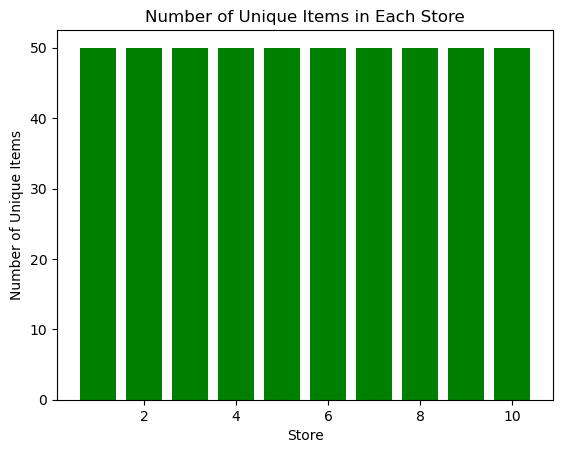

```python
# Group by store and count unique items
unique_items_per_store = df.groupby("store")["item"].nunique()

# Plotting bar graph
plt.bar(unique_items_per_store.index, unique_items_per_store.values, color='green')
plt.title('Number of Unique Items in Each Store')
plt.xlabel('Store')
plt.ylabel('Number of Unique Items')

# Show the plot
plt.show()
```

```python
# Are there equal numbers of sales in each store?
df.groupby(["store"]).agg({"sales": ["sum"]})
```

| store | sales sum |
| --- | --- |
| 1 | 4315603.0 |
| 2 | 6120128.0 |
| 3 | 5435144.0 |
| 4 | 5012639.0 |
| 5 | 3631016.0 |
| 6 | 3627670.0 |
| 7 | 3320009.0 |
| 8 | 5856169.0 |
| 9 | 5025976.0 |
| 10 | 5360158.0 |

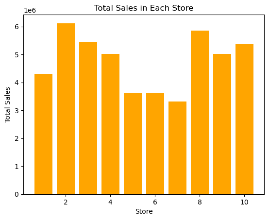

```python
# Group by store and sum the sales
total_sales_per_store = df.groupby("store")["sales"].sum()

# Plotting bar graph
plt.bar(total_sales_per_store.index, total_sales_per_store.values, color='orange')
plt.title('Total Sales in Each Store')
plt.xlabel('Store')
plt.ylabel('Total Sales')

# Show the plot
plt.show()
```

```python
# Sales statistics in store-item breakdown
df.groupby(["store", "item"]).agg({"sales": ["sum", "mean", "median", "std"]})
```

| store | item | sales sum | sales mean | sales median | sales std |
| --- | --- | --- | --- | --- | --- |
| 1 | 1 | 36468.0 | 19.971522 | 19.0 | 6.741022 |
|  | 2 | 97050.0 | 53.148959 | 52.0 | 15.005779 |
|  | 3 | 60638.0 | 33.208105 | 33.0 | 10.072529 |
|  | 4 | 36440.0 | 19.956188 | 20.0 | 6.640618 |
|  | 5 | 30335.0 | 16.612815 | 16.0 | 5.672102 |
| ... | ... | ... | ... | ... | ... |
| 10 | 46 | 120601.0 | 66.046550 | 65.0 | 18.114991 |
|  | 47 | 45204.0 | 24.755750 | 24.0 | 7.924820 |
|  | 48 | 105570.0 | 57.814896 | 57.0 | 15.898538 |
|  | 49 | 60317.0 | 33.032311 | 32.0 | 10.091610 |
|  | 50 | 135192.0 | 74.037240 | 73.0 | 19.937566 |

500 rows × 4 columns

# 3. FEATURE ENGINEERING

3.1 Date Features

```python
df['month'] = df.date.dt.month
df['day_of_month'] = df.date.dt.day
df['day_of_year'] = df.date.dt.dayofyear
df['week_of_year'] = df.date.dt.isocalendar().week
df['day_of_week'] = df.date.dt.dayofweek
df['year'] = df.date.dt.year
df["is_wknd"] = df.date.dt.weekday // 4
df['is_month_start'] = df.date.dt.is_month_start.astype(int)
df['is_month_end'] = df.date.dt.is_month_end.astype(int)

df.head()
```

|  | date | store | item | sales | id | month | day_of_month | day_of_year | week_of_year | day_of_week | year | is_wknd | is_month_start | is_month_end |
| --- | --- | --- | --- | --- | --- | --- | --- | --- | --- | --- | --- | --- | --- | --- |
| 0 | 2013-01-01 | 1 | 1 | 13.0 | NaN | 1 | 1 | 1 | 1 | 1 | 2013 | 0 | 1 | 0 |
| 1 | 2013-01-02 | 1 | 1 | 11.0 | NaN | 1 | 2 | 2 | 1 | 2 | 2013 | 0 | 0 | 0 |
| 2 | 2013-01-03 | 1 | 1 | 14.0 | NaN | 1 | 3 | 3 | 1 | 3 | 2013 | 0 | 0 | 0 |
| 3 | 2013-01-04 | 1 | 1 | 13.0 | NaN | 1 | 4 | 4 | 1 | 4 | 2013 | 1 | 0 | 0 |
| 4 | 2013-01-05 | 1 | 1 | 10.0 | NaN | 1 | 5 | 5 | 1 | 5 | 2013 | 1 | 0 | 0 |

Now that we have the month information, we can advance the descriptive analysis.

```python
df.groupby(["store", "item", "month"]).agg({"sales": ["sum", "mean", "median", "std"]})
```

| store | item | month | sales sum | sales mean | sales median | sales std |
| --- | --- | --- | --- | --- | --- | --- |
| 1 | 1 | 1 | 2125.0 | 13.709677 | 13.0 | 4.397413 |
|  |  | 2 | 2063.0 | 14.631206 | 14.0 | 4.668146 |
|  |  | 3 | 2728.0 | 17.600000 | 17.0 | 4.545013 |
|  |  | 4 | 3118.0 | 20.786667 | 20.0 | 4.894301 |
|  |  | 5 | 3448.0 | 22.245161 | 22.0 | 6.564705 |
| ... | ... | ... | ... | ... | ... | ... |
| 10 | 50 | 8 | 13108.0 | 84.567742 | 85.0 | 15.676527 |
|  |  | 9 | 11831.0 | 78.873333 | 79.0 | 15.207423 |
|  |  | 10 | 11322.0 | 73.045161 | 72.0 | 14.209171 |
|  |  | 11 | 11549.0 | 76.993333 | 77.0 | 16.253651 |
|  |  | 12 | 8724.0 | 56.283871 | 56.0 | 11.782529 |

6000 rows × 4 columns

At the moment, I have access to information about how much is sold in which store, from which item, in which month.

# 3.2 Random Noise

We add random values that are as large as the size of the dataframe to the new features we will create. Adding noise here prevents overfitting. It increases our prediction performance.

```python
def random_noise(dataframe):
    return np.random.normal(scale=1.6, size=(len(dataframe),))
```

# 3.3 Lag/Shifted Features

We will be producing features related to the sales numbers of the past period. Lag means delay. Shifted is also used in the same sense.

The time period t was most affected by t-1, sequentially from t-2. So we assume that the next day's sale of a store is affected by the previous day's sale, so we will need to derive features for that. These features will also create the values of the sales variable in previous periods. To do this, the data must be ordered according to store, item and date so that we can produce these features correctly.

```python
df.sort_values(by=['store', 'item', 'date'], axis=0, inplace=True)

df.head()
```

|  | date | store | item | sales | id | month | day_of_month | day_of_year | week_of_year | day_of_week | year | is_wknd | is_month_start | is_month_end |
| --- | --- | --- | --- | --- | --- | --- | --- | --- | --- | --- | --- | --- | --- | --- |
| 0 | 2013-01-01 | 1 | 1 | 13.0 | NaN | 1 | 1 | 1 | 1 | 1 | 2013 | 0 | 1 | 0 |
| 1 | 2013-01-02 | 1 | 1 | 11.0 | NaN | 1 | 2 | 2 | 1 | 2 | 2013 | 0 | 0 | 0 |
| 2 | 2013-01-03 | 1 | 1 | 14.0 | NaN | 1 | 3 | 3 | 1 | 3 | 2013 | 0 | 0 | 0 |
| 3 | 2013-01-04 | 1 | 1 | 13.0 | NaN | 1 | 4 | 4 | 1 | 4 | 2013 | 1 | 0 | 0 |
| 4 | 2013-01-05 | 1 | 1 | 10.0 | NaN | 1 | 5 | 5 | 1 | 5 | 2013 | 1 | 0 | 0 |

```python
df.groupby(["store", "item"])['sales'].head()
```

```
0         13.0
1         11.0
2         14.0
3         13.0
4         10.0
          ...
911174    33.0
911175    37.0
911176    46.0
911177    51.0
911178    41.0
Name: sales, Length: 2500, dtype: float64
```

Let's apply a delay of 1 to the whole dataset. So we calculated 1 lag of each value.

```python
df.groupby(["store", "item"])['sales'].transform(lambda x: x.shift(1))
```

```
0         NaN
1        13.0
2        11.0
3        14.0
4        13.0
         ...
44995     NaN
44996     NaN
44997     NaN
44998     NaN
44999     NaN
Name: sales, Length: 958000, dtype: float64
```

```python
def lag_features(dataframe, lags):
    for lag in lags:
        dataframe['sales_lag_' + str(lag)] = dataframe.groupby(["store", "item"])['sales'].transform(
            lambda x: x.shift(lag)) + random_noise(dataframe)
    return dataframe
```

Our main goal is to catch the trend, seasonality and level. Since this is a 3-month period, we have added it here as multiples of 3 months, 3 months +1 week, 3 months + 2 weeks, 6 months, etc.

```python
def random_noise(dataframe):
    return np.random.normal(scale=1.6, size=(len(dataframe),))

# Now you can use these functions
df = lag_features(df, [91, 98, 105, 112, 119, 126, 182, 364, 546, 728])
df.head()
```

|  | date | store | item | sales | id | month | day_of_month | day_of_year | week_of_year | day_of_week | year | is_wknd | is_month_start | is_month_end | sales_lag_91 | sales_lag_98 | sales_lag_105 | sales_lag_112 | sales_lag_119 | sales_lag_126 | sales_lag_182 | sales_lag_364 | sales_lag_546 | sales_lag_728 |
| --- | --- | --- | --- | --- | --- | --- | --- | --- | --- | --- | --- | --- | --- | --- | --- | --- | --- | --- | --- | --- | --- | --- | --- | --- |
| 0 | 2013-01-01 | 1 | 1 | 13.0 | NaN | 1 | 1 | 1 | 1 | 1 | 2013 | 0 | 1 | 0 | NaN | NaN | NaN | NaN | NaN | NaN | NaN | NaN | NaN | NaN |
| 1 | 2013-01-02 | 1 | 1 | 11.0 | NaN | 1 | 2 | 2 | 1 | 2 | 2013 | 0 | 0 | 0 | NaN | NaN | NaN | NaN | NaN | NaN | NaN | NaN | NaN | NaN |
| 2 | 2013-01-03 | 1 | 1 | 14.0 | NaN | 1 | 3 | 3 | 1 | 3 | 2013 | 0 | 0 | 0 | NaN | NaN | NaN | NaN | NaN | NaN | NaN | NaN | NaN | NaN |
| 3 | 2013-01-04 | 1 | 1 | 13.0 | NaN | 1 | 4 | 4 | 1 | 4 | 2013 | 1 | 0 | 0 | NaN | NaN | NaN | NaN | NaN | NaN | NaN | NaN | NaN | NaN |
| 4 | 2013-01-05 | 1 | 1 | 10.0 | NaN | 1 | 5 | 5 | 1 | 5 | 2013 | 1 | 0 | 0 | NaN | NaN | NaN | NaN | NaN | NaN | NaN | NaN | NaN | NaN |

# 3.4 Rolling Mean Features

This is the moving average. If I'm going to make predictions in a 3-month period, I need to show the patterns 3 months before that to my model.

```python
pd.DataFrame({"sales": df["sales"].values[0:10],
              "roll2": df["sales"].rolling(window=2).mean().values[0:10],
              "roll3": df["sales"].rolling(window=3).mean().values[0:10],
              "roll5": df["sales"].rolling(window=5).mean().values[0:10]})
```

|  | sales | roll2 | roll3 | roll5 |
| --- | --- | --- | --- | --- |
| 0 | 13.0 | NaN | NaN | NaN |
| 1 | 11.0 | 12.0 | NaN | NaN |
| 2 | 14.0 | 12.5 | 12.666667 | NaN |
| 3 | 13.0 | 13.5 | 12.666667 | NaN |
| 4 | 10.0 | 11.5 | 12.333333 | 12.2 |
| 5 | 12.0 | 11.0 | 11.666667 | 12.0 |
| 6 | 10.0 | 11.0 | 10.666667 | 11.8 |
| 7 | 9.0 | 9.5 | 10.333333 | 10.8 |
| 8 | 12.0 | 10.5 | 10.333333 | 10.6 |
| 9 | 9.0 | 10.5 | 10.000000 | 10.4 |

```python
pd.DataFrame({"sales": df["sales"].values[0:10],
              "roll2": df["sales"].shift(1).rolling(window=2).mean().values[0:10],
              "roll3": df["sales"].shift(1).rolling(window=3).mean().values[0:10],
              "roll5": df["sales"].shift(1).rolling(window=5).mean().values[0:10]})
```

|  | sales | roll2 | roll3 | roll5 |
| --- | --- | --- | --- | --- |
| 0 | 13.0 | NaN | NaN | NaN |
| 1 | 11.0 | NaN | NaN | NaN |
| 2 | 14.0 | 12.0 | NaN | NaN |
| 3 | 13.0 | 12.5 | 12.666667 | NaN |
| 4 | 10.0 | 13.5 | 12.666667 | NaN |
| 5 | 12.0 | 11.5 | 12.333333 | 12.2 |
| 6 | 10.0 | 11.0 | 11.666667 | 12.0 |
| 7 | 9.0 | 11.0 | 10.666667 | 11.8 |
| 8 | 12.0 | 9.5 | 10.333333 | 10.8 |
| 9 | 9.0 | 10.5 | 10.333333 | 10.6 |

```python
def roll_mean_features(dataframe, windows):
    for window in windows:
        dataframe['sales_roll_mean_' + str(window)] = dataframe.groupby(["store", "item"])['sales']. \
                                                          transform(
            lambda x: x.shift(1).rolling(window=window, min_periods=10, win_type="triang").mean()) + random_noise(
            dataframe)
    return dataframe


df = roll_mean_features(df, [365, 546])
df.tail()
```

|  | date | store | item | sales | id | month | day_of_month | day_of_year | week_of_year | day_of_week | year | is_wknd | is_month_start | is_month_end | sales_lag_91 | sales_lag_98 | sales_lag_105 | sales_lag_112 | sales_lag_119 | sales_lag_126 | sales_lag_182 | sales_lag_364 | sales_lag_546 | sales_lag_728 | sales_roll_mean_365 | sales_roll_mean_546 |
| --- | --- | --- | --- | --- | --- | --- | --- | --- | --- | --- | --- | --- | --- | --- | --- | --- | --- | --- | --- | --- | --- | --- | --- | --- | --- | --- |
| 44995 | 2018-03-27 | 10 | 50 | NaN | 44995.0 | 3 | 27 | 86 | 13 | 1 | 2018 | 0 | 0 | 0 | 41.444797 | 51.430317 | 65.280216 | 70.367691 | 68.587697 | 82.225286 | 76.866039 | 60.098184 | 95.068955 | 74.130042 | 87.529217 | 86.616829 |
| 44996 | 2018-03-28 | 10 | 50 | NaN | 44996.0 | 3 | 28 | 87 | 13 | 2 | 2018 | 0 | 0 | 0 | 61.290414 | 49.746033 | 67.176612 | 61.722585 | 79.144360 | 76.329514 | 81.882793 | 73.656654 | 78.983813 | 67.114883 | 85.403379 | 86.209390 |
| 44997 | 2018-03-29 | 10 | 50 | NaN | 44997.0 | 3 | 29 | 88 | 13 | 3 | 2018 | 0 | 0 | 0 | 56.833392 | 64.276080 | 72.373813 | 67.129138 | 73.235756 | 85.959655 | 83.361047 | 66.014582 | 98.917993 | 75.330321 | 86.335947 | 88.531913 |
| 44998 | 2018-03-30 | 10 | 50 | NaN | 44998.0 | 3 | 30 | 89 | 13 | 4 | 2018 | 1 | 0 | 0 | 73.303900 | 72.693258 | 73.157530 | 65.983971 | 62.824226 | 82.223228 | 92.270670 | 70.052373 | 80.798296 | 84.014449 | 85.939650 | 83.834529 |
| 44999 | 2018-03-31 | 10 | 50 | NaN | 44999.0 | 3 | 31 | 90 | 13 | 5 | 2018 | 1 | 0 | 1 | 64.844264 | 71.251939 | 51.525009 | 69.402864 | 50.847796 | 81.472729 | 103.128657 | 104.914812 | 96.529193 | 79.009088 | 86.622616 | 83.874957 |

# 3.5 Exponentially Weighted Mean Features

Here, as an example, I put a rolling mean and a weighted average with alpha values of 0.99, 0.95, 0.7 and 0.1.

The weighted average would give more weight to the closest values when the Alpha was 0.99, and would give more weight to the farthest values when it was 0.1.

```python
pd.DataFrame({"sales": df["sales"].values[0:10],
              "roll2": df["sales"].shift(1).rolling(window=2).mean().values[0:10],
              "ewm099": df["sales"].shift(1).ewm(alpha=0.99).mean().values[0:10],
              "ewm095": df["sales"].shift(1).ewm(alpha=0.95).mean().values[0:10],
              "ewm07": df["sales"].shift(1).ewm(alpha=0.7).mean().values[0:10],
              "ewm01": df["sales"].shift(1).ewm(alpha=0.1).mean().values[0:10]})
```

|  | sales | roll2 | ewm099 | ewm095 | ewm07 | ewm01 |
| --- | --- | --- | --- | --- | --- | --- |
| 0 | 13.0 | NaN | NaN | NaN | NaN | NaN |
| 1 | 11.0 | NaN | 13.000000 | 13.000000 | 13.000000 | 13.000000 |
| 2 | 14.0 | 12.0 | 11.019802 | 11.095238 | 11.461538 | 11.947368 |
| 3 | 13.0 | 12.5 | 13.970201 | 13.855107 | 13.287770 | 12.704797 |
| 4 | 10.0 | 13.5 | 13.009702 | 13.042750 | 13.084686 | 12.790637 |
| 5 | 12.0 | 11.5 | 10.030097 | 10.152137 | 10.920146 | 12.109179 |
| 6 | 10.0 | 11.0 | 11.980301 | 11.907607 | 11.676595 | 12.085878 |
| 7 | 9.0 | 11.0 | 10.019803 | 10.095380 | 10.502722 | 11.686057 |
| 8 | 12.0 | 9.5 | 9.010198 | 9.054769 | 9.450748 | 11.214433 |
| 9 | 9.0 | 10.5 | 11.970102 | 11.852738 | 11.235259 | 11.342672 |

When we take the exponential average of the 2 lags of 14, when we say give 0.99 weight to 11, 11.019802 is found. It's getting closer to 13 for 0.1. In fact, while the average of these two with the moving average is 12, when we say give weight to this first with alpha, the average changes.

Let's give lags and alphas as a combination to accommodate the influence of past periods. When we use lightgbm later, we will be waiting to see if features are produced against combinations such as Lag 91 & Alpha 0.95 or Lag 98 & Alpha 0.7 and which ones will be more meaningful.

```python
def ewm_features(dataframe, alphas, lags):
    for alpha in alphas:
        for lag in lags:
            dataframe['sales_ewm_alpha_' + str(alpha).replace(".", "") + "_lag_" + str(lag)] = \
                dataframe.groupby(["store", "item"])['sales'].transform(lambda x: x.shift(lag).ewm(alpha=alpha).mean())
    return dataframe

alphas = [0.95, 0.9, 0.8, 0.7, 0.5]
lags = [91, 98, 105, 112, 180, 270, 365, 546, 728]

df = ewm_features(df, alphas, lags)

df.tail()
```

|  | date | store | item | sales | id | month | day_of_month | day_of_year | week_of_year | day_of_week | year | is_wknd | is_month_start | is_month_end | sales_lag_91 | sales_lag_98 | sales_lag_105 | sales_lag_112 | sales_lag_119 | sales_lag_126 | sales_lag_182 | sales_lag_364 | sales_lag_546 | sales_lag_728 | sales_roll_mean_365 | sales_roll_mean_546 | sales_ewm_alpha_095_lag_91 | sales_ewm_alpha_095_lag_98 | sales_ewm_alpha_095_lag_105 | … |
| --- | --- | --- | --- | --- | --- | --- | --- | --- | --- | --- | --- | --- | --- | --- | --- | --- | --- | --- | --- | --- | --- | --- | --- | --- | --- | --- | --- | --- | --- | --- |
| 44995 | 2018-03-27 | 10 | 50 | NaN | 44995.0 | 3 | 27 | 86 | 13 | 1 | 2018 | 0 | 0 | 0 | 41.444797 | 51.430317 | 65.280216 | 70.367691 | 68.587697 | 82.225286 | 76.866039 | 60.098184 | 95.068955 | 74.130042 | 87.529217 | 86.616829 | 41.561777 | 54.028375 | 66.387487 | … |
| 44996 | 2018-03-28 | 10 | 50 | NaN | 44996.0 | 3 | 28 | 87 | 13 | 2 | 2018 | 0 | 0 | 0 | 61.290414 | 49.746033 | 67.176612 | 61.722585 | 79.144360 | 76.329514 | 81.882793 | 73.656654 | 78.983813 | 67.114883 | 85.403379 | 86.209390 | 61.928089 | 51.151419 | 66.969374 | … |
| 44997 | 2018-03-29 | 10 | 50 | NaN | 44997.0 | 3 | 29 | 88 | 13 | 3 | 2018 | 0 | 0 | 0 | 56.833392 | 64.276080 | 72.373813 | 67.129138 | 73.235756 | 85.959655 | 83.361047 | 66.014582 | 98.917993 | 75.330321 | 86.335947 | 88.531913 | 59.146404 | 62.407571 | 71.748469 | … |
| 44998 | 2018-03-30 | 10 | 50 | NaN | 44998.0 | 3 | 30 | 89 | 13 | 4 | 2018 | 1 | 0 | 0 | 73.303900 | 72.693258 | 73.157530 | 65.983971 | 62.824226 | 82.223228 | 92.270670 | 70.052373 | 80.798296 | 84.014449 | 85.939650 | 83.834529 | 73.257320 | 74.370379 | 71.987423 | … |
| 44999 | 2018-03-31 | 10 | 50 | NaN | 44999.0 | 3 | 31 | 90 | 13 | 5 | 2018 | 1 | 0 | 1 | 64.844264 | 71.251939 | 51.525009 | 69.402864 | 50.847796 | 81.472729 | 103.128657 | 104.914812 | 96.529193 | 79.009088 | 86.622616 | 83.874957 | 62.562866 | 70.218519 | 52.999371 | … |

```python
df.shape
```

```
(958000, 71)
```

In the beginning we had 4 variables

# 3.6 One-Hot Encoding

```python
df = pd.get_dummies(df, columns=['store', 'item', 'day_of_week', 'month'])
df.shape
```

```
(958000, 146)
```

The number of variables increased from 71 to 146.

# 3.7 Converting sales to log(1+sales)

```python
df['sales'] = np.log1p(df["sales"].values)
df.head()
```

|  | date | sales | id | day_of_month | day_of_year | week_of_year | year | is_wknd | is_month_start | is_month_end | sales_lag_91 | sales_lag_98 | sales_lag_105 | sales_lag_112 | sales_lag_119 | sales_lag_126 | sales_lag_182 | sales_lag_364 | sales_lag_546 | sales_lag_728 | sales_roll_mean_365 | sales_roll_mean_546 | sales_ewm_alpha_095_lag_91 | sales_ewm_alpha_095_lag_98 | sales_ewm_alpha_095_lag_105 | sales_ewm_alpha_095_lag_112 | sales_ewm_alpha_095_lag_180 | sales_ewm_alpha_095_lag_270 | sales_ewm_alpha_095_lag_365 | … |
| --- | --- | --- | --- | --- | --- | --- | --- | --- | --- | --- | --- | --- | --- | --- | --- | --- | --- | --- | --- | --- | --- | --- | --- | --- | --- | --- | --- | --- | --- | --- |
| 0 | 2013-01-01 | 2.639057 | NaN | 1 | 1 | 1 | 2013 | 0 | 1 | 0 | NaN | NaN | NaN | NaN | NaN | NaN | NaN | NaN | NaN | NaN | NaN | NaN | NaN | NaN | NaN | NaN | NaN | NaN | NaN | … |
| 1 | 2013-01-02 | 2.484907 | NaN | 2 | 2 | 1 | 2013 | 0 | 0 | 0 | NaN | NaN | NaN | NaN | NaN | NaN | NaN | NaN | NaN | NaN | NaN | NaN | NaN | NaN | NaN | NaN | NaN | NaN | NaN | … |
| 2 | 2013-01-03 | 2.708050 | NaN | 3 | 3 | 1 | 2013 | 0 | 0 | 0 | NaN | NaN | NaN | NaN | NaN | NaN | NaN | NaN | NaN | NaN | NaN | NaN | NaN | NaN | NaN | NaN | NaN | NaN | NaN | … |
| 3 | 2013-01-04 | 2.639057 | NaN | 4 | 4 | 1 | 2013 | 1 | 0 | 0 | NaN | NaN | NaN | NaN | NaN | NaN | NaN | NaN | NaN | NaN | NaN | NaN | NaN | NaN | NaN | NaN | NaN | NaN | NaN | … |
| 4 | 2013-01-05 | 2.397895 | NaN | 5 | 5 | 1 | 2013 | 1 | 0 | 0 | NaN | NaN | NaN | NaN | NaN | NaN | NaN | NaN | NaN | NaN | NaN | NaN | NaN | NaN | NaN | NaN | NaN | NaN | NaN | … |

# 4. MODELLING

Submissions are evaluated in this competition on SMAPE (Symmetric mean absolute percentage error (adjusted MAPE)) so we will define a function in order to evaluate the difference between forecasts and actual values. When we use SMAPE it allows us to evaluate an error as a percentage

```python
def smape(preds, target):
    n = len(preds)
    masked_arr = ~((preds == 0) & (target == 0))
    preds, target = preds[masked_arr], target[masked_arr]
    num = np.abs(preds - target)
    denom = np.abs(preds) + np.abs(target)
    smape_val = (200 * np.sum(num / denom)) / n
    return smape_val
```

In summary, our cost functioncompares the estimated values with the actual values. It then takes their absolute values and converts them to percentage form.

```python
def lgbm_smape(preds, train_data):
    labels = train_data.get_label()
    smape_val = smape(np.expm1(preds), np.expm1(labels))
    return 'SMAPE', smape_val, False
```

We also define a lgbm_smape function to optimize the lightgbm function accordingly. We need to translate this custom cost function into the language that lightgbm understands. We have done a logarithmic transformation before. We will have the opportunity to apply this to the smape function, which will also undo this logarithmic transformation.

# 4.1 Time-Based Validation Sets

Kaggle asks us to predict the first 3 months of 2018 in the test set. The train set is between January 2013 and December 2017.

I need to do something like that, I have to create 2 sets within the set given to me as a train set. One must be train and the other must be validation. When we randomly divide the train and validation sets, our date context will be broken, so we need to manually separate the train and validation sets, not randomly.

Let's create our train set until the beginning of 2017, and let's take the first 3 months of 2017 as a validation set.

```python
train = df.loc[(df["date"] < "2017-01-01"), :]

val = df.loc[(df["date"] >= "2017-01-01") & (df["date"] < "2017-04-01"), :]

cols = [col for col in train.columns if col not in ['date', 'id', "sales", "year"]]

Y_train = train['sales']
X_train = train[cols]

Y_val = val['sales']
X_val = val[cols]

Y_train.shape, X_train.shape, Y_val.shape, X_val.shape
```

```
((730500,), (730500, 142), (45000,), (45000, 142))
```

# 4.2 LightGBM Model

```python
pip install --upgrade lightgbm
```

```python
# LightGBM parameters
lgb_params = {
    'metric': 'mae',  # Change this to 'mae' if that's the metric you want to use
    'num_leaves': 10,
    'learning_rate': 0.02,
    'feature_fraction': 0.8,
    'max_depth': 5,
    'num_boost_round': 1000,
    'early_stopping_rounds': 200,
    'nthread': -1
}

# Create LightGBM datasets
lgbtrain = lgb.Dataset(data=X_train, label=Y_train, feature_name=cols)
lgbval = lgb.Dataset(data=X_val, label=Y_val, reference=lgbtrain, feature_name=cols)

# Train the model
model = lgb.train(
    lgb_params,
    lgbtrain,
    valid_sets=[lgbtrain, lgbval],
    num_boost_round=lgb_params['num_boost_round'],
    feval=lgbm_smape
)
```

```
[LightGBM] [Info] Auto-choosing col-wise multi-threading, the overhead of testing was 0.251584 seconds.
You can set `force_col_wise=true` to remove the overhead.
[LightGBM] [Info] Total Bins 15033
[LightGBM] [Info] Number of data points in the train set: 730500, number of used features: 142
[LightGBM] [Info] Start training from score 3.789881
Training until validation scores don't improve for 200 rounds
Did not meet early stopping. Best iteration is:
[1000]	training's l1: 0.130073	training's SMAPE: 13.3516	valid_1's l1: 0.13472	valid_1's SMAPE: 13.8438
```

# 4.3 Feature Importance

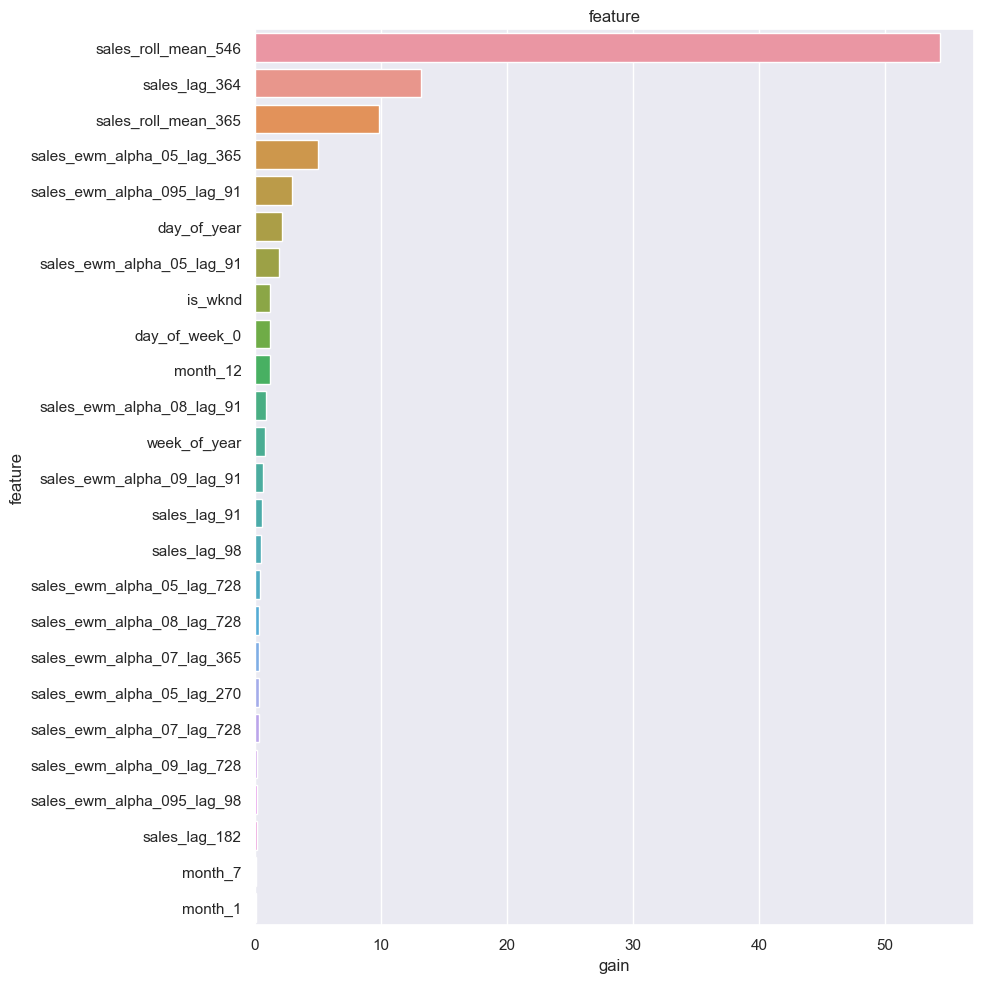

```python
def plot_lgb_importances(model, plot=False, num=10):

    gain = model.feature_importance('gain')
    feat_imp = pd.DataFrame({'feature': model.feature_name(),
                             'split': model.feature_importance('split'),
                             'gain': 100 * gain / gain.sum()}).sort_values('gain', ascending=False)
    if plot:
        plt.figure(figsize=(10, 10))
        sns.set(font_scale=1)
        sns.barplot(x="gain", y="feature", data=feat_imp[0:25])
        plt.title('feature')
        plt.tight_layout()
        plt.show()
    else:
        print(feat_imp.head(num))

plot_lgb_importances(model, num=30, plot=True)

plt.show()
```

Our newly derived features are at the top of the ranking.

# 4.3 Final Model

When we focus on NaN values of 'sales' in the dataframe, we know that this will correspond to the test set. We brought together 2 dataframes, in which the train set with sales parts and the test set without.

```python
train = df.loc[~df.sales.isna()]
Y_train = train['sales']
X_train = train[cols]

test = df.loc[df.sales.isna()]
X_test = test[cols]

lgb_params = {'metric': {'mae'},
              'num_leaves': 10,
              'learning_rate': 0.02,
              'feature_fraction': 0.8,
              'max_depth': 5,
              'verbose': 0,
              'nthread': -1,
              "num_boost_round": model.best_iteration}
```

```python
# LightGBM dataset
lgbtrain_all = lgb.Dataset(data=X_train, label=Y_train, feature_name=cols)

model = lgb.train(lgb_params, lgbtrain_all, num_boost_round=model.best_iteration)

test_preds = model.predict(X_test, num_iteration=model.best_iteration)
```

# 5 Submission

```python
submission_df = test.loc[:, ['id', 'sales']]
submission_df['sales'] = np.expm1(test_preds)
submission_df['id'] = submission_df.id.astype(int)

submission_df.to_csv('submission.csv', index=False)
submission_df.head()
```

|  | id | sales |
| --- | --- | --- |
| 0 | 0 | 12.074672 |
| 1 | 1 | 14.723656 |
| 2 | 2 | 13.921567 |
| 3 | 3 | 14.902821 |
| 4 | 4 | 18.289222 |

id: The 'id' column contains unique identifiers for each data point. In the displayed output, the ids are sequential integers starting from 0.

sales: The 'sales' column contains the predicted sales values. These values have been transformed back to the original scale using the np.expm1 function. This function is commonly used to reverse the log transformation that might have been applied to the target variable during the modeling phase.